# Republika: a Very Cool Polish Band from the 80s-90s

Author

Nina Smolinska

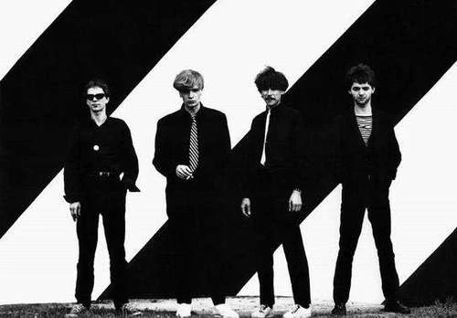

## Who’s Republika?

The Republic (Polish: Republika) was a Polish rock band formed in 1981 in Toruń, as a result of the transformation of the art rock band “Res Publica”. From the very beginning, it was associated with the “Od Nowa” Student Club in Toruń at the Nicolaus Copernicus University, where it performed concerts and held rehearsals. As a result of disagreements, Republika broke up in 1986, only to return in 1990. In the 1990s, the band was actively involved in recording and performing. In 2001, after the death of its leader and vocalist Grzegorz Ciechowski, it was definitively dissolved. <sup>[1](https://new-wave.fandom.com/pl/wiki/Republika)</sup>

## A Quote:

> *“My friends from many places*

> *What a procession, what a beautiful march*

> *They march shoulder to shoulder straight ahead In slippers, in suits*

> *With pajamas under their arms*

> *With jobs, with taxes, and with white flags*

> *They march, crowds of them, crowds of them.”*

> *- Republika in song “White Flag” which criticises the people who as they grow up, start conforming to and mindlessly obeying institutions, while abandoning their rebellious side which fights for justice. Hence the white flag as a symbol of surrender of an individual.*

## Republika’s Full Albums

[figure not shown]

## Republika’s Concert Albums

[figure not shown]

## Some of Republika’s Most Popular Songs

[video not shown]

# Data Sourcing and Processing

## Data Sourcing

The Data on Republika’s songs on Spotify was downloaded from the server link provided by Professor Joy Lee. The attributes converted to numeric scales include:

- acousticness
- danceability
- energy
- instrumentalness
- liveness
- loudness
- speechiness
- tempo
- valence

For more information on Spotify audio features click this [link](https://help.spotontrack.com/article/what-do-the-audio-features-mean).

Unfortunately, not all Republika’s songs are on Spotify. Out of 8 albums and 4 live concert albums, only 6 are on Spotify. This includes:

- “1984” (1984 English Version)
- “Republika Marzeń” *“The Republic of Dreams”* (1995)
- “Masakra” *“Massacre”* (1998)
- “Nowe Sytuacje” *“New Situations”* (2001 Remastered)
- “Nieustanne Tango” *“Everlasting Tango”* (2002 Remastered)
- “Republika” *“The Republic”* (2002)

This is quite upsetting as some of their most popular songs like “Zawsze Ty (Klatka)” *“Always You (Cage)”* are not present on Spotify at all, even in the Remastered or Live Concert albums. This is most likely a copyright and record label issue.

## Data Processing

First, I loaded the libraries I will be using:

```r
#Importing packages needed for the analysis
library(ggplot2)
library(dplyr)
library(readr)
library(forcats)
library(tidyr)
```

Republika’s song names contain Polish characters like “ń”, “ł”, “ś”, etc. Upon download from the Spotify server link all Polish characters were lost and replaced with “?” in the csv. file. I manually replaced these “?” with the correct Polish characters. However, R also recognized the Polish characters as not letters, again making the Polish characters appear as “?”. This is an encoding issue. The text is stored as bytes in the .csv, in order for R to read these bytes as characters it uses different mapping techniques called encoding. As I did not set any encoding when telling R to read the .cvs, it used the default encoding technique which in this case, resulted in lost Polish characters as the encoding technique used does not support them. We can ask R about which encoding technique should be used:

```r
#Asking R what the Ecoding is to make sure the Polish characters are preserved
guess_encoding("Republika_Data_78.csv", n_max = 1000)
```

```
# A tibble: 2 × 2
  encoding     confidence
  <chr>             <dbl>
1 windows-1250       0.31
2 windows-1252       0.26
```

Then, I imported the data by indicating the proper encoding technique: Windows-1250. The data was then cleaned from any empty spaces.

```r
#Importing data
df <- read.csv("Republika_Data_78.csv", fileEncoding = "Windows-1250")

#Cleaning data by removing any empty spaces
df <- df %>%
  rename_with(trimws) %>%
  mutate(across(where(is.character), ~trimws(.x)))
```

However, the data set was still looking rough. Some song titles contain commas, example : “Obejmij mnie, Czeczenio” *“Embrace me, Chechnya”.* Other songs contain quitation marks, example: “Znak”=” *“Sign”=“.* Thus, the data was misaliged in these rows. To fix these issues, in 3 tracks commas and quotation marks were removed.

With the data set looking clean, I wanted to check how many records are there (77):

```r
#How many records?
nrow(df)
```

```
[1] 77
```

Then duplicates were removed:

```r
#Duplicates removed based on Song title
df <- dplyr::distinct(df, Song, .keep_all = TRUE)

#Duplicates removed based on same values accorss collumns
df <- dplyr::distinct(df, Acousticness, Danceability, Energy, Instrumentalness, Liveness, Loudness, Speechiness, Tempo, Valence, .keep_all = TRUE)

#Checking how many records are left after removing duplicates
nrow(df)
```

```
[1] 76
```

Overall the data set has 76 unique records, there was only 1 duplicate.

This is interesting, as some songs in the data set are remastered versions, live versions and remixes. Below is a table of original and the remastered versions showing that indeed, they are different. This makes sense for the Live (Śmierć w bikini - Live) vs CD (Śmierć W Bikini) version as I expected acousticness and instrumentalness to change; but it is surprising for the CD Polish version (Śmierć W Bikini) vs CD English version (Bikini Death - 2002 Remaster) as the only difference between them is language. Funnily enough, the Polish version scores lower on valence (is more sad), energy and loudness.

```r
df %>%
  filter(Song %in% c("Śmierć W Bikini", "Bikini Death - 2002 Remaster", "Śmierć w bikini - Live")) %>%
  knitr::kable(digits = 3, caption="The Different Versions of 'Śmierć w Bikini'")
```

The Different Versions of ‘Śmierć w Bikini’

| Song | Acousticness | Danceability | Energy | Instrumentalness | Liveness | Loudness | Speechiness | Tempo | Valence |
| --- | --- | --- | --- | --- | --- | --- | --- | --- | --- |
| Śmierć W Bikini | 0.004 | 0.730 | 0.633 | 0.003 | 0.060 | -10.849 | 0.129 | 147.900 | 0.751 |
| Bikini Death - 2002 Remaster | 0.004 | 0.679 | 0.863 | 0.000 | 0.056 | -7.053 | 0.040 | 145.760 | 0.927 |
| Śmierć w bikini - Live | 0.224 | 0.634 | 0.874 | 0.013 | 0.951 | -7.209 | 0.047 | 143.666 | 0.824 |

## Assigning Songs to Albums

To do my analysis, I need to assign the songs to their respective albums. To do so I input an additional “Album” column in the .csv file. However, I run to some issues. First one being encoding which I already know how to solve, so let’s ask R what encoding is required:

```r
#Asking R what the Ecoding is to make sure the Polish characters are preserved
guess_encoding("Republika_Data_2.csv", n_max = 1000)
```

```
# A tibble: 3 × 2
  encoding     confidence
  <chr>             <dbl>
1 UTF-8              1
2 windows-1250       0.33
3 windows-1252       0.28
```

Now we know that we should set the encoding to UTF-8.

Other issues I ran into is R not being able to delimit the rows properly. Therefore, I specified the deliminator as “;” and the decimals between numbers as “.”

```r
#Reading the .csv file
df2 <- read_delim(
  "Republika_Data_2.csv",
  delim = ";",
  locale = locale(encoding = "UTF-8", decimal_mark = ".")
)
```

Another issue I ran into was that the first row of the csv. was “Column 1”, “Column 2”, etc. , while the second was the actual attributes: “Song”, “Album” etc. . To fix this, I have renamed “Column 1” to “Song” etc. and deleted the row with “Song”, “Album” etc. which was understood as a data, not data header row. Then, the data was cleaned and columns with numbers were turned to numeric to ensure that a statistical analysis can be performed.

```r
df2 <- df2 %>%
  rename(
    Song = Column1,
    Album = Column12,
    Acousticness = Column2,
    Danceability = Column3,
    Energy = Column4,
    Instrumentalness = Column5,
    Liveness = Column6,
    Loudness = Column7,
    Speechiness = Column8,
    Tempo = Column9,
    Valence = Column10
  ) %>%
  filter(Song != "Song") %>%
  mutate(
    Song  = trimws(Song),
    Album = trimws(Album),
    across(c(Acousticness, Danceability, Energy, Instrumentalness,
             Liveness, Loudness, Speechiness, Tempo, Valence), as.numeric)
  )
```

# Data Analysis

## Valence

As Republika is within the post-punk / new wave genre, I would expect their music over all albums to score low in valence which describes musical positivity conveyed by a track on a scale from 1-0. With 0 being depressing, angry, sad and 1 being positive, happy, euphoric. A box plot and histogram of valence across albums below visualize the trend. Surprisingly, they don’t score low, instead the median of all albums is above 0.5. The least positive albums are “Republika” *“The Republic”*, “Masakra” *“Massacre”*, “Nieustanne Tango” *“Everlasting Tango”* with a median valence of approximately 0.57. Meanwhile the most positive album is the English version of “1984” with median of approximately 0.8. Perghaps there really is some truth to music in Polish being more sad compared to music in English.

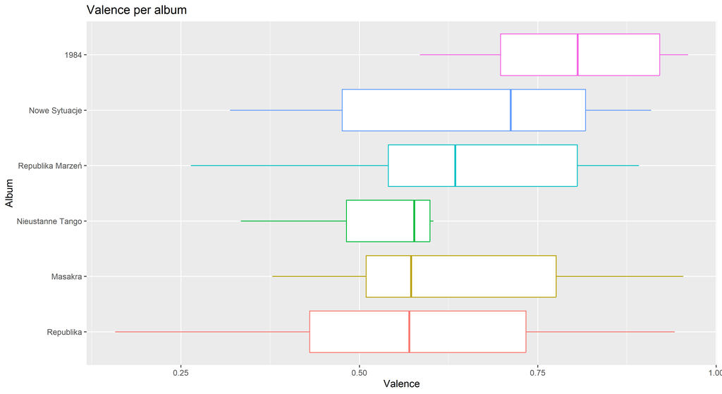

```r
df2 %>%
  filter(!is.na(Album), !is.na(Valence)) %>%
  mutate(
    Album = trimws(Album),
    Album = fct_reorder(Album, Valence, .fun = median, .na_rm = TRUE)
  ) %>%
  ggplot(aes(x = Album, y = Valence, color = Album)) +
  geom_boxplot() +
  coord_flip() +
  labs(
    title = "Valence per album",
    x = "Album",
    y = "Valence",
    colour = "Album"
  ) +
  guides(color = "none")
```

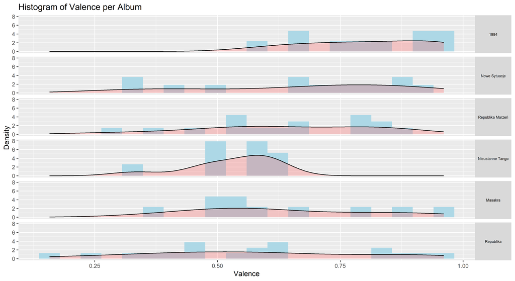

```r
df2 %>%
  filter(!is.na(Album), !is.na(Valence)) %>%
  mutate(Album = fct_rev(fct_reorder(Album, Valence, .fun = median, .na_rm = TRUE))) %>%
  ggplot(aes(x = Valence)) +
  geom_histogram(aes(y = after_stat(density)), bins = 20, fill = "lightblue") +
  geom_density(fill = "#FF6666", alpha = 0.3) +
  facet_grid(Album ~ .) +
  labs(title = "Histogram of Valence per Album", x = "Valence", y = "Density") +
  theme(strip.text.y = element_text(size = 6, angle = 0))
```

Let’s see what the top 3 most depressing and the top 3 most positive songs are and compare that to their actual message/theme:

```r
df2 %>%
  filter(!is.na(Valence)) %>%
  arrange(Valence) %>%
  select(Song, Album, Valence) %>%
  slice_head(n=3) %>%
  knitr::kable(digits = 3, caption="Top 3 Low Valence Songs (Most Depressing Songs)")
```

Top 3 Low Valence Songs (Most Depressing Songs)

| Song | Album | Valence |
| --- | --- | --- |
| Tak długo czekam (Ciało) - Live | Republika | 0.158 |
| Jestem w niebie - Live | Republika | 0.238 |
| Dar dla Pana B. | Republika Marzeń | 0.264 |

“Tak Długo Czekam (Ciało) - Live” *“I’ve been waiting for so long (Body) - Live”* makes sense as the most depressing/sad song of Republika. In it, the genious of the band’s sensual lyricism takes front stage, as the song is all about yearning for closeness in a quite possessive, dark and direct way.

“Jestem w Niebie - Live” *“I am in Heaven - Live”* has a spiritual and calm sound. The live version especially makes the overall atmosphere somber. In it, the frontman Grzegorz Ciechowski romantically sings about being with a loved one which he describes like being in heaven. The lyrics make use of religious symbolism. Again, this ranking makes sense.

“Dar dla Pana B.” *“A Gift for Mr. G.”* also has a spiritual sound, you can hear lots of the signature flute of Grzegorz Ciechowski. The song also uses religious symbology and is literally a gift for God, a prayer in a way. In it, Republika wishes for everyone to overcome their struggles. However, despite the hearfelt message, the song does not sound so sad or very calm.

```r
df2 %>%
  filter(!is.na(Valence)) %>%
  slice_max(Valence, n = 3, with_ties = FALSE) %>%
  select(Song, Album, Valence) %>%
  slice_head(n=3) %>%
  knitr::kable(digits = 3, caption="Top 3 High Valence Songs (Most Positive)")
```

Top 3 High Valence Songs (Most Positive)

| Song | Album | Valence |
| --- | --- | --- |
| The Current - 2002 Remastered Version | 1984 | 0.961 |
| Mamona | Masakra | 0.954 |
| Siberia - 2002 Remaster | 1984 | 0.947 |

Funnily enough, the two English remastered versions of 1984 songs are in the top 3 positive songs of Republika. This again is interesting to see, as “The Current - 2002 Remastered Version” has its original Polish counterpart in this data set which did not make it to the top 3 or top 5 (I have checked!) list. Regardless, I do not think that “The Current” should score that high in valence as towards the end of the song the singer is screaming and the track gets distorted …. The song is about desire filtered through a metaphore or electricity - desire is strong like an electric current but once the attraction reaches certain ambigious levels it can get painful and confusing with the desire of the other to pull away (the singer constantly shouts “Ouch!” in the song). Therefore, I am overall not so sure how this song made it to the top.

“Mamona” *“Money”* is a positive classic in which Republika is transparent about corruption and how the music industry is all about the money. So, they embrace this and made a song where they state “this song was created for money” in the chorus. It is very upbeat and carefree.

“Siberia - 2002 Remaster” is another English version which Polish version - “Arktyka” is in the data set as well but doesn’t score so high on valence. The melody of the song is groovy and positive. However, the message behind the song is not. It is about the coldness that creeps into relationships, as well as describing the communist times in Poland as cold. Perhaps not considering the lyrics, the song fits on the list.

## Danceability

I’m also interested in mapping the danceability accross albums as I expect it to be high as their music is rather groovy. The score of 0 indicates low danceability, while 1 indicates high danceability.

The results show that indeed, Republika’s music is rather danceable as the median score ranges between approximately 0.5 and 0.7. The album that’s most dancable is “Republika Marzeń” *“The Republic of Dreams”*, while the least dancealbe album is “Nieustanne Tango” *“Everlasting Tango”*. It also makes sense that the album with the largest range of danceability is “Republika” “The Republic” as it contains a compliation of live songs across all eras of Republika.

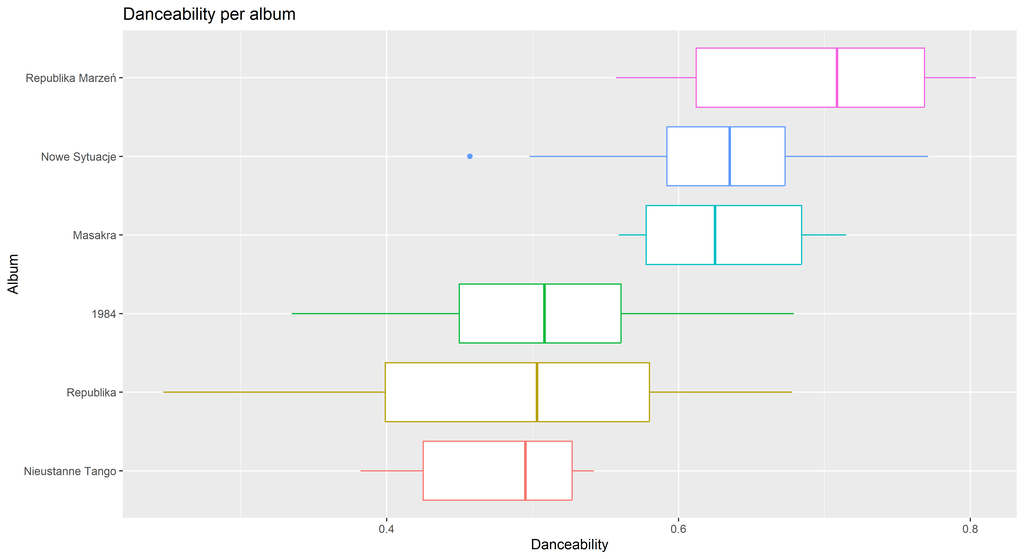

```r
library(dplyr)
library(ggplot2)
library(forcats)

df2 %>%
  filter(!is.na(Album), !is.na(Danceability)) %>%
  mutate(
    Album = trimws(Album),
    Album = fct_reorder(Album, Danceability, .fun = median, .na_rm = TRUE)
  ) %>%
  ggplot(aes(x = Album, y = Danceability, color = Album)) +
  geom_boxplot() +
  coord_flip() +
  labs(
    title = "Danceability per album",
    x = "Album",
    y = "Danceability",
    colour = "Album"
  ) +
  guides(color = "none")
```

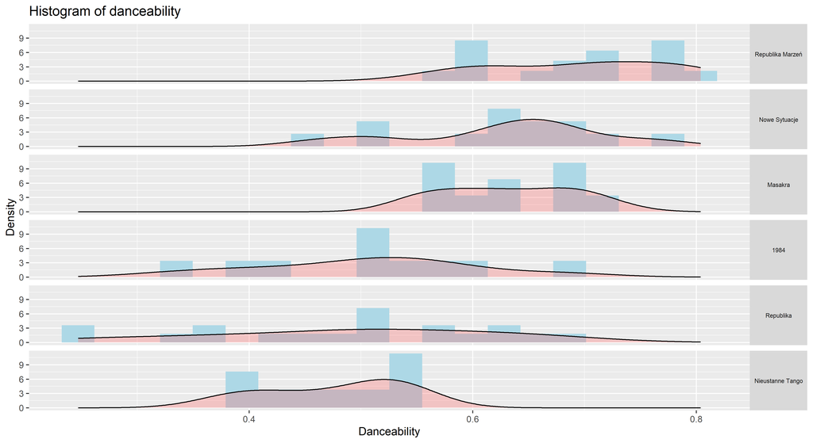

```r
df2 %>%
  filter(!is.na(Album), !is.na(Danceability)) %>%
  mutate(Album = fct_rev(fct_reorder(Album, Danceability, .fun = median, .na_rm = TRUE))) %>%
  ggplot(aes(x = Danceability)) +
  geom_histogram(aes(y = after_stat(density)), bins = 20, fill = "lightblue") +
  geom_density(fill = "#FF6666", alpha = 0.3) +
  facet_grid(Album ~ .) +
  labs(title = "Histogram of danceability", x = "Danceability", y = "Density") +
  theme(strip.text.y = element_text(size = 6, angle = 0))
```

What is this outlier in “Nowe Sytuacje” *“New Situations”* that is so undanceable compared to other songs in the album?

```r
df2 %>%
  filter(Album == "Nowe Sytuacje", !is.na(Danceability)) %>%
  arrange(Danceability) %>%
  select(Song, Danceability) %>%
  slice(1) %>%
  knitr::kable(digits = 3)
```

| Song | Danceability |
| --- | --- |
| Będzie Plan | 0.457 |

This is very surprising as this song is very rythmic and groovy, hence danceable, especially during concerts. Perhaps the reason why it is so not danceable are the dynamic shifts in the song between high and low energy. Below is the song in question:

[video not shown]

I also wanted to check what are the least danceable songs in general:

```r
df2 %>%
  filter(!is.na(Danceability)) %>%
  arrange(Danceability) %>%
  select(Song, Album, Danceability) %>%
  slice_head(n=5) %>%
  knitr::kable(digits = 3, caption="Top 5 Least Danceable Songs")
```

Top 5 Least Danceable Songs

| Song | Album | Danceability |
| --- | --- | --- |
| Tak długo czekam (Ciało) - Live | Republika | 0.247 |
| Prośba do następcy - Live | Republika | 0.261 |
| My Imperialism | 1984 | 0.335 |
| Halucynacje - Live | Republika | 0.349 |
| Kombinat - Live | Republika | 0.357 |

On the contrary, this makes sense. The song “Tak Długo Czekam (Ciało)” *“I’ve been waiting so long (Body)”* is very sensual, dark and slow. It is one of my and my mum’s favourites. The song is below:

[video not shown]

However, the other songs “My Imperialism” , “Kombinat - Live” *“Combine - Live”* are rather danceable in my opinion. Perhaps they again fall victim to the language change from Polish to English in “My Imperialism” case, as well as tempo/energy changes within the song. Overall, I would place “Halucynacje - Live” *“Hallucinations - Live”* as the 3rd least danceable song rather than what is listed in the table.

What is the most danceable song?

```r
df2 %>%
  filter(!is.na(Danceability)) %>%
  slice_max(Danceability, n = 1, with_ties = FALSE) %>%
  select(Song, Album, Danceability) %>%
  knitr::kable(digits = 3, caption="Most Danceable Song")
```

Most Danceable Song

| Song | Album | Danceability |
| --- | --- | --- |
| Józef K | Republika Marzeń | 0.804 |

“Józef K.” is full of playful instrumental with lots of guitar. However, it is definitley not the most danceable.

## Valence and Danceability

After analysing both valence and danceability separatley, let’s instead combine them and see if there is any trend. The scatterplot shows that most songs lie in the middle values of danceability and valence. Most of the songs with high valence also tend to be more danceable. Predictably, the results of the linear correlation show that there is a moderate positive linear relationship between these two variables.

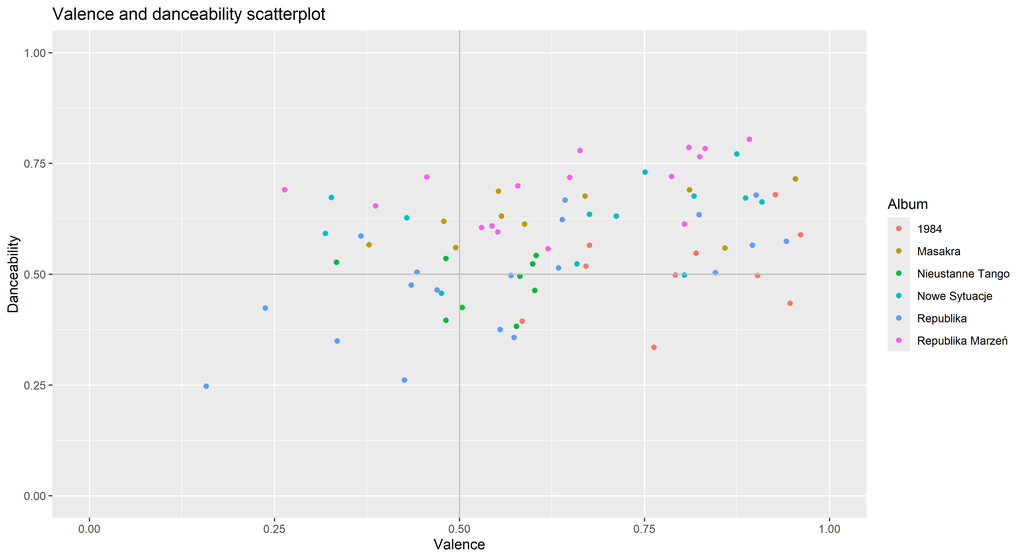

```r
df2 %>%
  ggplot(aes(x = Valence, y = Danceability, color = Album))+
  geom_point()+
  geom_hline(yintercept = 0.5, color="grey")+
  geom_vline(xintercept = 0.5, color="grey") +
  xlim(0, 1)+ ylim(0,1)+
  labs(title="Valence and danceability scatterplot")
```

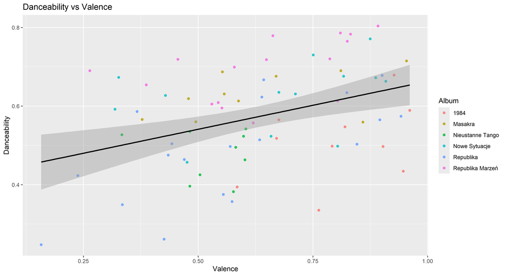

```r
df_plot <- df2 %>%
  filter(!is.na(Valence), !is.na(Danceability))

ggplot(df_plot, aes(x = Valence, y = Danceability, color = Album)) +
  geom_point(alpha = 0.8) +
  geom_smooth(method = "lm", se = TRUE, color = "black") +
  labs(
    title = "Danceability vs Valence",
    x = "Valence",
    y = "Danceability",
    colour = "Album"
  )
```

```r
pear  <- cor.test(df_plot$Valence, df_plot$Danceability, method = "pearson")
spear <- cor.test(df_plot$Valence, df_plot$Danceability, method = "spearman")
mod   <- lm(Danceability ~ Valence, data = df_plot)

results <- tibble::tibble(
  Test = c("Pearson correlation", "Spearman correlation", "Linear regression"),
  Statistic = c(unname(pear$estimate), unname(spear$estimate), summary(mod)$r.squared),
  `p-value` = c(pear$p.value, spear$p.value, NA_real_)
)

knitr::kable(results, digits = 4)
```

| Test | Statistic | p-value |
| --- | --- | --- |
| Pearson correlation | 0.3830 | 0.0006 |
| Spearman correlation | 0.3429 | 0.0023 |
| Linear regression | 0.1467 | NA |

## Tempo Across Albums

Overall, Republika’s songs are in the moderate tempo region which is not surprising as they have a variety of speed across their songs. In the violin chart below, we can see how the songs in “Nieustanne Tango” *“Everlasting Tango”* are all clustered in the 125-150 BPM while songs in “Republika Marzeń” *“The Republic of Dreams”* are overall slower as they cluster in 90-120 BPM.

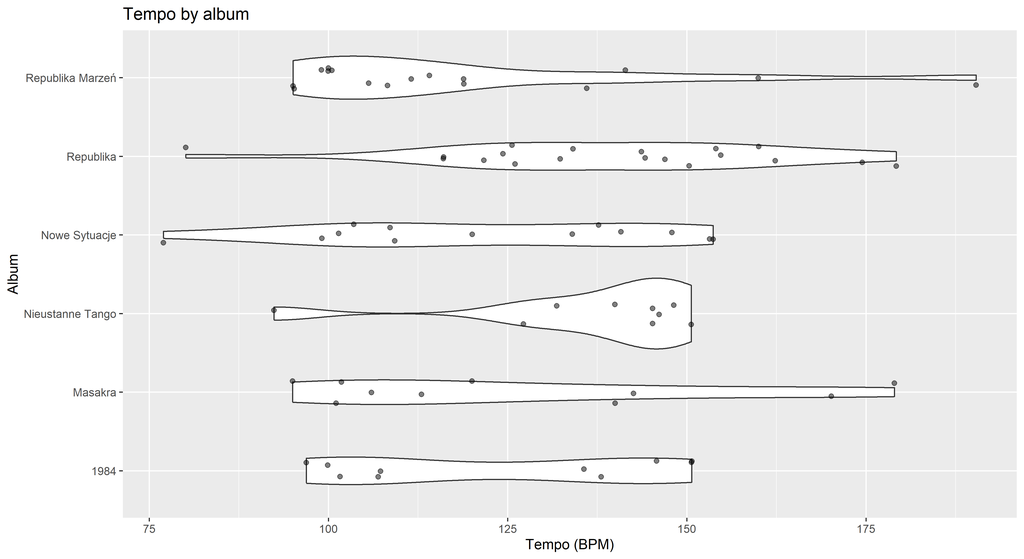

```r
df2 %>%
  filter(!is.na(Album), !is.na(Tempo)) %>%
  ggplot(aes(x = Album, y = Tempo)) +
  geom_violin() +
  geom_jitter(width = 0.15, alpha = 0.5) +
  coord_flip() +
  labs(title = "Tempo by album", x = "Album", y = "Tempo (BPM)")
```

Now, let’s see what the fastest and slowest songs are:

```r
tempo_two <- df2 %>%
  filter(!is.na(Tempo)) %>%
  arrange(Tempo) %>%
  slice(c(1, n())) %>%
  select(Song, Album, Tempo)

knitr::kable(tempo_two, digits = 2, caption="The Slowest and the Fastest Song")
```

The Slowest and the Fastest Song

| Song | Album | Tempo |
| --- | --- | --- |
| Śmierć W Bikini - Remix 2001 | Nowe Sytuacje | 76.98 |
| Zapytaj mnie czy Cię kocham - Dance Floor Mix | Republika Marzeń | 190.36 |

The slowest song is “Śmierć W Bikini - Remix 2001” *“Bikini Death - Remix 2001”* which makes perfect sense, as this version of the song is made to be more low-key, relaxing and lo-fi. Meanwhile the fastest song is also a remix, the dance floor mix of “Zapytaj Czy Cię Kocham” *“Ask me if I Love You - Dance Floor Mix”* - again makes perfect sense as it is the dance floor mix meant to be fast.

## Scatter Plot of Energy and Valence

After having a look at valence, I wanted to analyze Republika’s overall mood in detail. Especially considering the different moods - sad, peaceful, sensual - of songs that score lowest in valence. To do so, I have constructed a scatterplot of energy and valence. Overall, most of Republika’s songs are joyful, while the second most common mood is angry. Within the data set, there were only 4 sad songs and 2 peaceful songs.

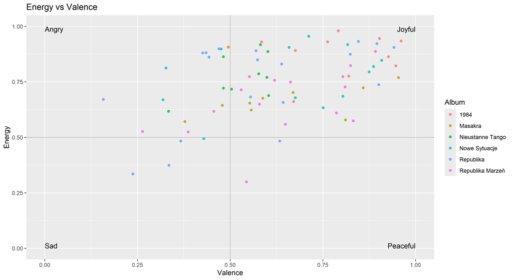

```r
df_plot <- df2 %>%
  filter(!is.na(Valence), !is.na(Energy))

ggplot(df_plot, aes(x = Valence, y = Energy, color = Album)) +
  geom_point(alpha = 0.8) +
  geom_hline(yintercept = 0.5, color = "grey") +
  geom_vline(xintercept = 0.5, color = "grey") +
  annotate("text", x = 0, y = 1, label = "Angry",  hjust = 0, vjust = 1, inherit.aes = FALSE) +
  annotate("text", x = 1, y = 1, label = "Joyful", hjust = 1, vjust = 1, inherit.aes = FALSE) +
  annotate("text", x = 0, y = 0, label = "Sad", hjust = 0, vjust = 0, inherit.aes = FALSE) +
  annotate("text", x = 1, y = 0, label = "Peaceful", hjust = 1, vjust = 0, inherit.aes = FALSE) +
  labs(title = "Energy vs Valence", x = "Valence", y = "Energy", color = "Album")
```

I also want to specifically identify the top joyful, angry, sad and peaceful songs:

```r
df_plot <- df2 %>%
  filter(!is.na(Valence), !is.na(Energy))

closest_to <- function(df, x0, y0) {
  df %>%
    mutate(dist = (Valence - x0)^2 + (Energy - y0)^2) %>%
    slice_min(dist, n = 1, with_ties = FALSE) %>%
    select(Song, Album, Valence, Energy)
}

moods <- bind_rows(
  Joyful   = closest_to(df_plot, 1, 1),
  Angry    = closest_to(df_plot, 0, 1),
  Sad      = closest_to(df_plot, 0, 0),
  Peaceful = closest_to(df_plot, 1, 0),
  .id = "Mood"
)

knitr::kable(moods, digits = 3, caption= "The Most Joyful, Angry, Sad and Peaceful Songs")
```

The Most Joyful, Angry, Sad and Peaceful Songs

| Mood | Song | Album | Valence | Energy |
| --- | --- | --- | --- | --- |
| Joyful | The Current - 2002 Remastered Version | 1984 | 0.961 | 0.934 |
| Angry | Tak długo czekam (Ciało) - Live | Republika | 0.158 | 0.671 |
| Sad | Jestem w niebie - Live | Republika | 0.238 | 0.335 |
| Peaceful | Jej brzuch | Republika Marzeń | 0.544 | 0.299 |

I have already talked enough about “Tak Długo Czekam (Ciało)” *“I’ve been Waiting for so Long (Body)”*. It perfectly fits the angry mood with its sinister bass melody and lyrics like:

> *“I’ve been* waiting *for so long that my hands are at the brink of starvation”*

> *“Your body is for me”*

The previously discussed song “The Current - 2002 Remastered Version” does not make sense as the most joyful song as discussed above.

The only placements on this list that perhaps make sense are “Jestem w Niebie - Live” *“I am in Heaven - Live”* and “Jej Brzuch” *“Her Stomach”.* As discussed above, “Jestem w Niebie - Live” is calm, not necessarily sad but still, it is partially sad in tone. “Jej Brzuch” is 100% a very calm song, it is an appreciation towards women and miracle of pregnancy, where the singer is awaiting his child.

# Takeaway

Overall, the Spotify audio features were at times not so in line with the experts - the two generations of Republika fans (me and my mother). I also found it interesting how language seemed to play a part in creating completely different values for one song of English versus Polish versions. Still, the data set made a conclusion that valence and danceability have a moderate positive linear correlation, therefore it can not be so wrong afterall. It was also fun to create a style for the .html with the .css custom file. [This website](https://quarto.org/docs/guide/)was very helpful in making all these cosmetic changes.